# Soil apparent electrical conductivity (ECa)

# Learning Objectives

Today, our objectives are to:

- Discuss about apparent soil electrical conductivity (ECa) and what it is
- Discuss how it is measured
- Discuss why it is an important layer in precision ag

## What is electrical conductivity (EC)?

- Measure of how much electrical current is conducted through a medium, measured in **Siemens or milliSiemens/meter (S or mS/m)**
- Relates to level of ionic charges able to conduct electrical current
- Initially developed to measure salt concentration in soil water and relate it back to crop growing suitability (saline/sodic soils)

## How has it been traditionally measured in soils?

- Soil sample is collected on the field, brought to a laboratory, saturated with water, and its extractant measured for electrical conductivity (ECe) between two electrodes.
- Time-consuming and labor-intensive, not feasible for PA applications.

## What is bulk soil apparent electrical conductivity (ECa)?

Bulk soil apparent electrical conductivity measures EC of bulk soil (liquid and solid phases).

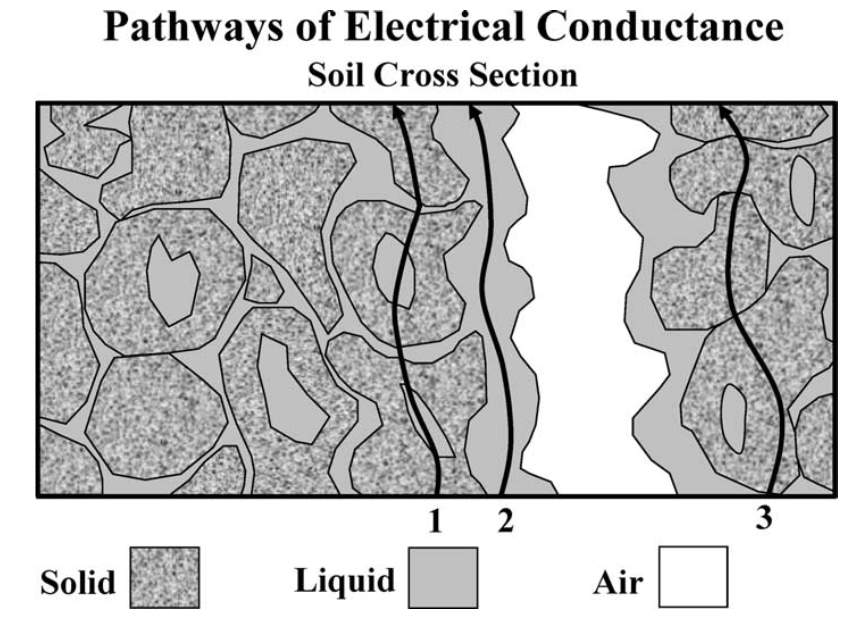

## How can soil ECa be measured in-situ?

Three methods exist to measure in-situ bulk soil ECa:

1. Electrical resistivity
2. Electromagnetic induction
3. Time-domain reflectometry (TDR)

## 1. Electrical resistivity

Commercial example: Veris 3100

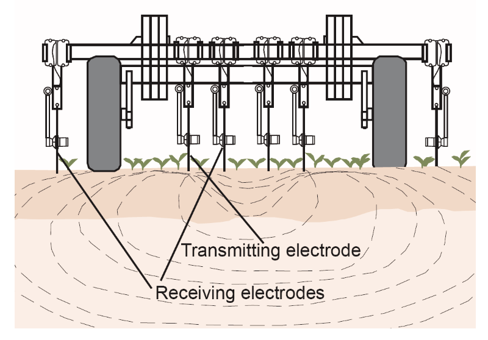

Different disk distances relate to different soil depths.

## 2. Electromagnetic induction

Commercial example: Geonics EM38

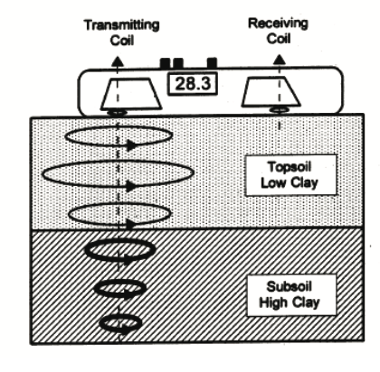

Fixed depth, no flexibility to change it.

## 3. Time-domain reflectometry (TDR)

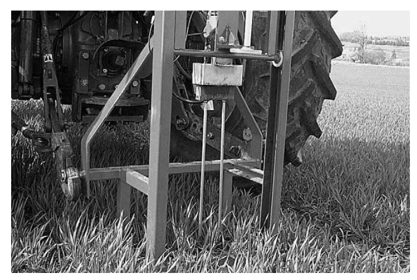

Least scalable among the in-situ methods.

## What affects soil ECa?

- **Soil salinity**
- **Soil water content**
- **Soil texture**
- Soil temperature
- Soil organic matter content
- Soil bulk density/porosity

Because it is affected by so many factors, soil ECa data can only be interpreted within the context of a given field, and not used to compare across fields.

## **soil salinity** vs. soil ECa

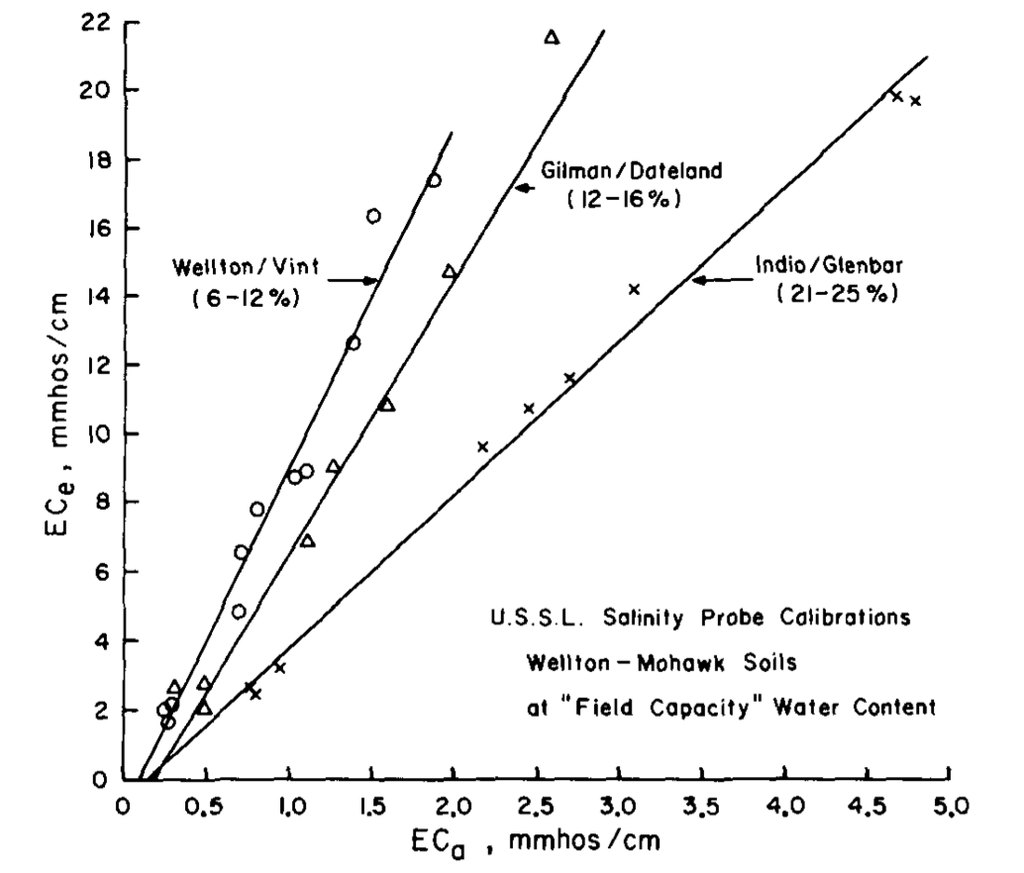

- As solution salinity (ECe) increases, bulk soil conductivity (ECa) also increases
- Different lines are different soils

## **soil water content** vs. soil ECa

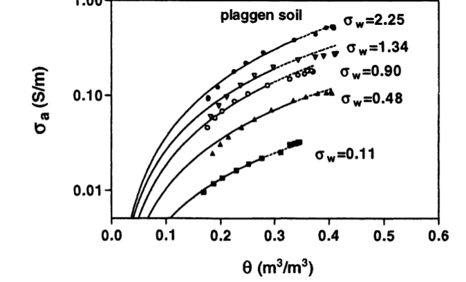

- As soil volumetric water content ($\theta$) increases, bulk soil conductivity (ECa = $\sigma_a$) increases, modulated by solution salinity (ECe = $\sigma_w$)
- Important when taking EC data, need similar levels of soil moisture across a field for quality EC data

## **soil texture** vs. soil ECa

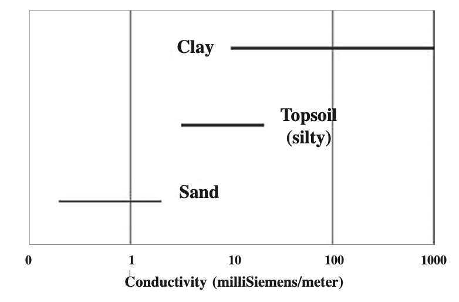

## Why is soil ECa important in PA?

When soil ECa is mostly **controlled by texture**, it can be used to create texture-based zones.

Important in PA as texture can be correlated with yield limiting factors like water/nutrient availability and CEC.

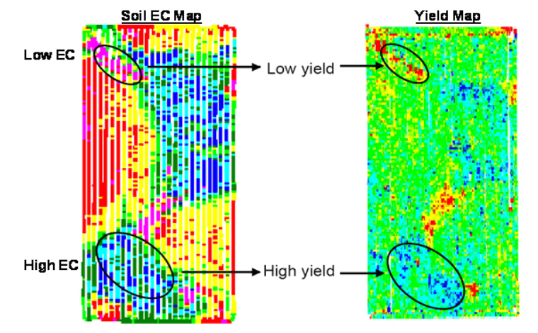

## Quiz

- Overall, is lower or higher ECa better for crop yield?
- Why?
- Can you think of and describe a case where it may be the opposite relationship as what you answered first?

# Let’s move to R and work with soil ECa data…